# Cluster level Statistics for single cell expression data

Vishwa Talati

2022-06-29

# Interview Task Instructions

Bonus Task:

- Load the data in Seurat
- Use `addModuleScore` function to calculate the scores of each gene module in each cell.
- Illustrate gene module score on a graph using UMAP coordinates for each gene module and save results as files.

Input files:

- Expression Data
- Metadata
- Gene Module annotation

# Overview

This Rmd is meant to demonstrate the steps involved in the processing of given gene2cell expression data as input file all the way to performing downstream analysis where it calculates the cluster level statistics.

# Dependencies

```
## Attaching SeuratObject
```

```
## Attaching sp
```

# Loading the data and looking into input files

To load the input files in csv format, `read.table` function is used. Following is the description for each of the input files:

- Expression Data: Represents expression levels of gene per cell combination
- Metadata: Represents cell to cluster mapping in order to group cells into clusters
- Gene annotation: Represents module number for each gene (M1,M2,M3)

The following code chunk also prepares the data for further processing.

```r
expression_data <- read.table("AG_matrix.csv", sep = ",", header = T)
metadata <- read.table("AG_metadata.csv", sep = ",", header = T)
genemodule <- read.table("GeneModule.csv", sep = ",", header = T)

##checking the dimension of expression data
dim(expression_data)
```

```
## [1] 13955 15281
```

```r
##preparing the data to read as Seurat object
#setting the rownames as Gene
rownames(expression_data) <- expression_data$Gene

#dropping the extra column with Gene names
expression_data <- subset(expression_data, select = -Gene)
```

# Seurat object generation and understanding various slots of it

In order to work with the expression data and perform cluster level statistics, I will use [Seurat](https://www.rdocumentation.org/packages/Seurat/versions/4.1.1) package. It is a package that has the required toolkit to perform Quality control, analysis and exploration of single cell data.

The very first step is to load the expression data as Seurat object which is an R class object for single cell data using `CreateSeuratObject` function. I will explore this Seurat object in order to see how the information is stored.

The expression counts are stored within the assay named “RNA”.

The meta.data slot is where you can add the sample level metadata information about the seurat object.Since there is no sample level metadata information, this slot just calculates a couple of QC summary statistics like nCount_RNA and nFeature_RNA by default.

Another important parameter to be considered is percent.mt. Following is the explanation to each of these terms:

- nCount_RNA: Total number of molecules detected within a cell.
- n_Feature_RNA: Number of genes detected in each cell.
- percent.mt: High mitochondrial gene content often represents low quality of cells which is why it is important to calculate this and filter mitochondrial genes based on percent.mt.

```r
## we remove the genes with less than 3 cells and cells with less than 200 genes since they don't add meaning to the downstream analysis
ag_seurat <- CreateSeuratObject(counts = expression_data, min.cells = 3, min.features = 200, project = "Interview Task to calculate cluster level statistics")

##this seurat object has one assay called RNA where counts are stored
ag_seurat
```

```
## An object of class Seurat
## 10765 features across 6655 samples within 1 assay
## Active assay: RNA (10765 features, 0 variable features)
```

```r
##check the assays within the seurat object (currently just 1: RNA)
Assays(ag_seurat)
```

```
## [1] "RNA"
```

```r
##prints dimensions of count data which has reduced compared to the input expression matrix due to our specifications used while generating the seurat object
dim(ag_seurat[["RNA"]])
```

```
## [1] 10765  6655
```

```r
## this is the slot which stores the metadata
head(ag_seurat@meta.data, 5)
```

```
##                                  orig.ident nCount_RNA nFeature_RNA
## G0_Channel1___AAACCTGAGAGTGAGA.1         G0        317          208
## G0_Channel1___AAACCTGCATCACCCT.1         G0        726          203
## G0_Channel1___AAACCTGTCGCGCCAA.1         G0        622          229
## G0_Channel1___AAACGGGAGCAATCTC.1         G0        556          239
## G0_Channel1___AAACGGGCACAACGCC.1         G0        432          210
```

```r
##the above mentioned are some of the slots that are already populated. Other slots can be populated as you move forward in the analysis.
```

# Checking the quality of the data and visualization

Before visualizing the important QC features listed above, I will first calculate the percent.mt explained above using `PercentateFeatureSet` function.

The next step is to visualize these QC features using `FeatureScatter` plot and `VlnPlot` function from Seurat package.

From the `meta.data` slot, it can be seen that percent.mt values are all zeroes. One of the possible reasons could be due to use of different species like Drosophila meaning the data does not belong to human or mouse genome. The way mitochondrial genes are named in human or mouse reference is different than that in Drosophila and this might be a reason why the code pattern is not able to grab the MT genes from the data.

Also looking at the `orig.ident` column of the meta.data slot and `Vlnplot`, it is safe to assume that the expression data has counts for two samples namely G0 and G1.

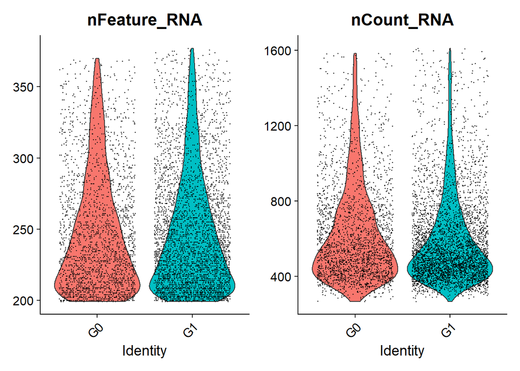

```r
##percent.mt has zero values.
ag_seurat[["percent.mt"]] <- PercentageFeatureSet(ag_seurat, pattern = "^MT-")

VlnPlot(ag_seurat, features = c("nFeature_RNA", "nCount_RNA"), ncol = 2 )
```

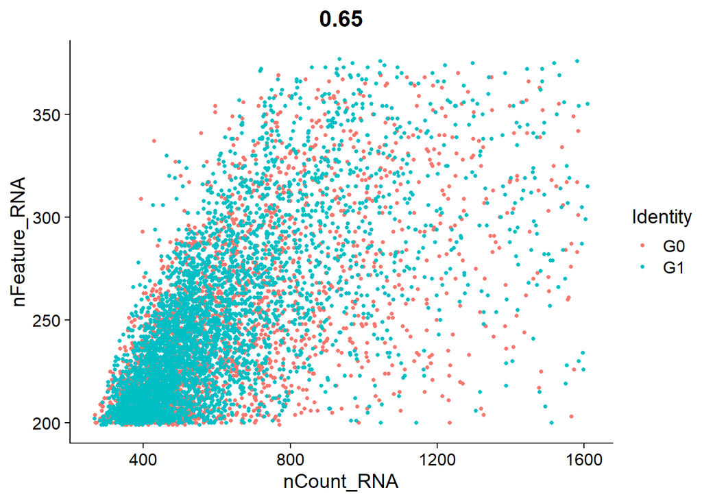

```r
#this plot shows feature:feature relationship
FeatureScatter(ag_seurat, feature1 = "nCount_RNA", feature2 = "nFeature_RNA")
```

```r
#filtering the low quality cells
# filtered_seurat <- subset(x = ag_seurat,
#                          subset= (nCount_RNA >= 450) &
#                            (nFeature_RNA > 250))
# b <- VlnPlot(filtered_seurat, features = c("nFeature_RNA", "nCount_RNA"), ncol = 2, )
# a + labs(title = "After filtering")
#
# a / b
```

# Normalization and Pre-processing

However, since the data seems to have two samples (G0, G1), I first split the seurat object as a list of 2 seurat objects using `SplitObject` function.

Following to normalization, the next step is to find subset of features which exhibit high cell to cell variation. This is done using `FindVariableFeatures` function. These genes in turn help to find biological signals during downstream analysis.

```r
ag_seuratlist <-  SplitObject(ag_seurat, split.by = "orig.ident")

ag_seuratlist <- lapply(X = ag_seuratlist, FUN = function(x) {
  x <- NormalizeData(x)
  x <- FindVariableFeatures(x, selection.method = "vst", nfeatures = 2000)

})

# this helps to get the repeatedly variable features across both objects in the list
ag_features <- SelectIntegrationFeatures(object.list = ag_seuratlist)
```